# Lab 3

Ethan Wanlass, Haley Bruan

9/26/2019

## Background

The General Social Survey (GSS) has been run by NORC every other year since 1972 to keep track of current opinions across the United States. We are working with an excerpt of the dataset that covers years 1972 to 2016. The variable names along with a brief description are as follows:

| Variable | Description |
| --- | --- |
| Year | Year for this respondent |
| Age | Age of respondent |
| Sex | Sex of respondent |
| …. | ….. |

Now it’s important to understand what each column stands for. You can find a codebook with explanations for each of the variables at https://gssdataexplorer.norc.org/

## Data Cleaning

Initial exploration revealed that some data processing was needed before we could proceed with further visualization. All missing values were encoded with ‘NA’ as follows:

```r
HAPPY <- readRDS("HAPPY.rds")
names(HAPPY) = tolower(names(HAPPY))

na_before = length(which(is.na(HAPPY)))

HAPPY$happy = replace(HAPPY$happy, HAPPY$happy %in% c("IAP", "DK","NA"),NA)
HAPPY$year = replace(HAPPY$year, HAPPY$year %in% c("IAP", "DK","NA"), NA)
HAPPY$age = replace(HAPPY$age, HAPPY$age %in% c("IAP", "DK","NA"), NA)
HAPPY$sex = replace(HAPPY$sex, HAPPY$sex %in% c("IAP", "DK","NA"), NA)
HAPPY$marital = replace(HAPPY$marital, HAPPY$marital %in% c("IAP", "DK","NA"), NA)
HAPPY$degree = replace(HAPPY$degree, HAPPY$degree %in% c("IAP", "DK","NA"), NA)
HAPPY$finrela = replace(HAPPY$finrela, HAPPY$finrela %in% c("IAP", "DK","NA"), NA)
HAPPY$health = replace(HAPPY$health, HAPPY$health %in% c("IAP", "DK","NA"), NA)
HAPPY$wtssall = replace(HAPPY$wtssall, HAPPY$wtssall %in% c("IAP", "DK","NA"), NA)
HAPPY$partyid = replace(HAPPY$partyid, HAPPY$partyid %in% c("IAP", "DK","NA"), NA)
HAPPY$polviews = replace(HAPPY$polviews, HAPPY$polviews %in% c("IAP", "DK","NA"), NA)

na_after = length(which(is.na(HAPPY)))

number_changed = na_after - na_before
number_changed
```

```
## [1] 30272
```

In total there were `30272 number of missing values.

Variables were also cast into the correct type in order to ease data visualization. This was done by casting the variables to factors or numeric depending on the type of data.

```r
HAPPY$age[HAPPY$age == "89 OR OLDER"] = "89"
HAPPY$age = as.numeric(HAPPY$age)

HAPPY$happy = as.factor(HAPPY$happy)
HAPPY$year = as.numeric(HAPPY$year)
HAPPY$sex = as.factor(HAPPY$sex)
HAPPY$degree = as.factor(HAPPY$degree)
HAPPY$marital = as.factor(HAPPY$marital)
HAPPY$finrela = as.factor(HAPPY$finrela)
HAPPY$health = as.factor(HAPPY$health)
HAPPY$wtssall = as.numeric(HAPPY$wtssall)
HAPPY$partyid = as.factor(HAPPY$partyid)
HAPPY$polviews = as.factor(HAPPY$polviews)
str(HAPPY)
```

```
## 'data.frame':    62466 obs. of  11 variables:
##  $ happy   : Factor w/ 3 levels "NOT TOO HAPPY",..: 1 1 2 1 2 2 1 1 2 2 ...
##  $ year    : num  1972 1972 1972 1972 1972 ...
##  $ age     : num  23 70 48 27 61 26 28 27 21 30 ...
##  $ sex     : Factor w/ 2 levels "FEMALE","MALE": 1 2 1 1 1 2 2 2 1 1 ...
##  $ marital : Factor w/ 5 levels "DIVORCED","MARRIED",..: 3 2 2 2 2 3 1 3 3 2 ...
##  $ degree  : Factor w/ 5 levels "BACHELOR","GRADUATE",..: 1 5 3 1 3 3 3 1 3 3 ...
##  $ finrela : Factor w/ 5 levels "ABOVE AVERAGE",..: 2 1 2 2 1 1 1 2 2 3 ...
##  $ health  : Factor w/ 4 levels "EXCELLENT","FAIR",..: 3 2 1 3 3 3 1 3 1 2 ...
##  $ wtssall : num  0.445 0.889 0.889 0.889 0.889 ...
##  $ partyid : Factor w/ 8 levels "IND,NEAR DEM",..: 1 4 3 4 7 1 1 1 7 7 ...
##  $ polviews: Factor w/ 7 levels "CONSERVATIVE",..: NA NA NA NA NA NA NA NA NA NA ...
```

```r
HAPPY$marital = factor(HAPPY$marital, levels = c("NEVER MARRIED", "MARRIED", "DIVORCED", "SEPERATED", "WIDOWED"))
HAPPY$finrela = factor(HAPPY$finrela, levels = c("FAR BELOW AVERAGE", "BELOW AVERAGE", "AVERAGE", "ABOVE AVERAGE", "FAR ABOVE AVERAGE"))
HAPPY$health = factor(HAPPY$health, levels = c("POOR", "FAIR", "GOOD", "EXCELLENT"))
HAPPY$partyid = factor(HAPPY$partyid, levels = c("STRONG DEMOCRAT", "NOT STR DEMOCRAT", "IND,NEAR DEM", "INDEPENDENT", "IND,NEAR REP", "NOT STR REPUBLICAN", "STRONG REPUBLICAN", "OTHER PARTY", NA))
HAPPY$polviews = factor(HAPPY$polviews, levels = c("EXTREMELY LIBERAL", "LIBERAL", "SLIGHTLY LIBERAL", "MODERATE", "SLIGHTLY CONSERVATIVE", "CONSERVATIVE", "EXTREMELY CONSERVATIVE"))
```

## Data Exploration

Two variables of interest are `age` and `political parties. Their distributions are as follow:

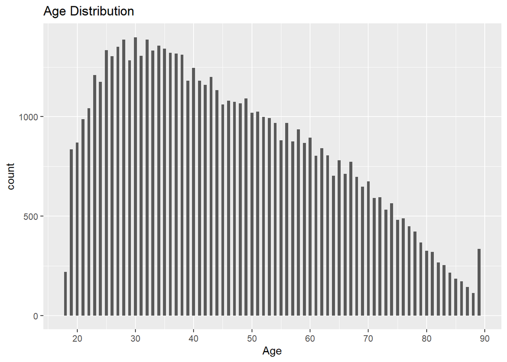

```r
library(ggplot2)

ggplot(HAPPY, aes(age)) + geom_histogram(binwidth = .5) + labs(title = 'Age Distribution')+ scale_x_continuous(name = "Age",breaks=c(10,20,30,40,50,60,70,80,90))
```

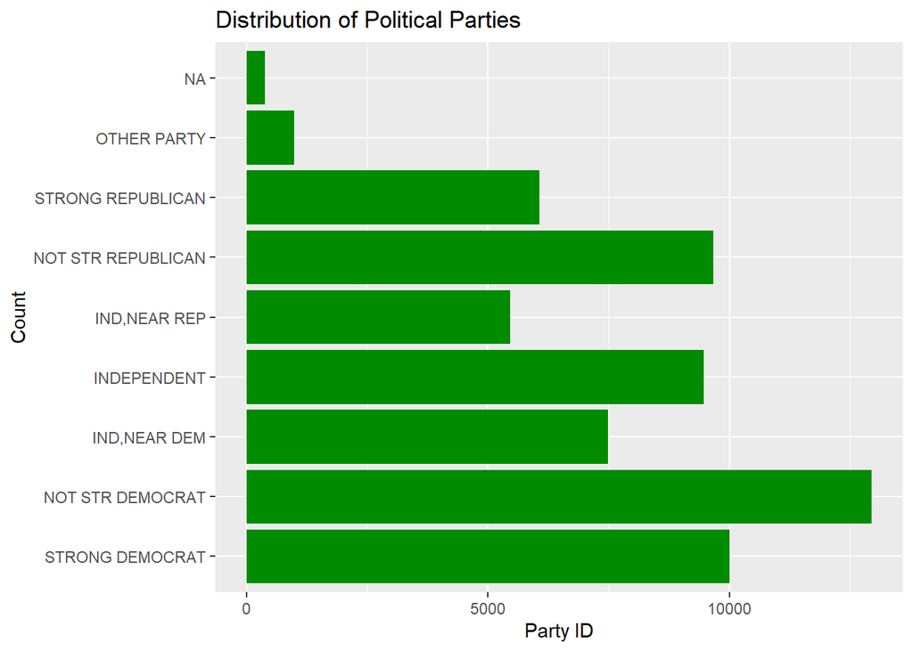

```r
ggplot(HAPPY, aes(partyid)) + geom_bar(fill = 'green4') + coord_flip() + ylab("Party ID") + xlab("Count") + labs(title = "Distribution of Political Parties")
```

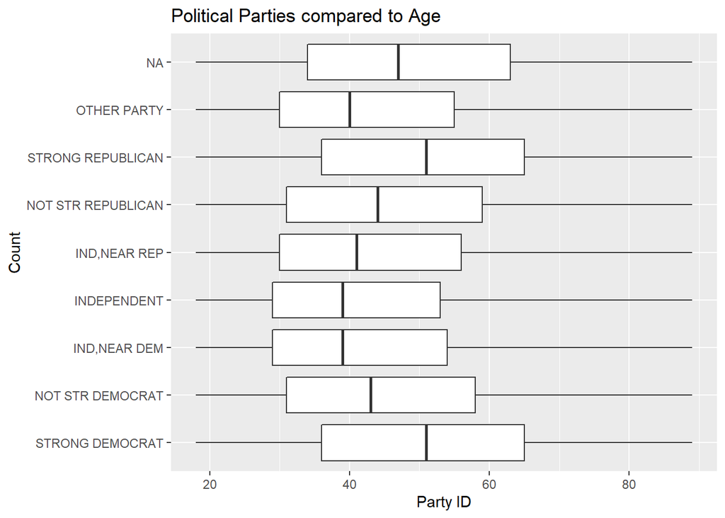

```r
ggplot(HAPPY, aes(partyid,age)) + geom_boxplot() + coord_flip() + ylab("Party ID") + xlab("Count") + labs(title = "Political Parties compared to Age")
```

Looking at the Age distribution, we can determine that most common age of the participants in the survey were between 25 and 35. After 35 is there is a slow decline in the average participants. Additionally, there is a large gap between before 20 and 20. At 89 there is a large influx of participants because of the data recorded anything after or at 89 in the same category.

From the boxplot comparing political parties and age we can see that the median age is pretty comparable between all of the parties. We can see a slight relationship that older age is more likely to attribute to a stronger political party affiliation.

```r
library(ggmosaic)
HAPPY$happy = droplevels(HAPPY$happy)
HAPPY$marital = droplevels(HAPPY$marital)
HAPPY$health = droplevels(HAPPY$health)
HAPPY$sex = droplevels(HAPPY$sex)
levels(HAPPY$sex)
```

```
## [1] "FEMALE" "MALE"
```

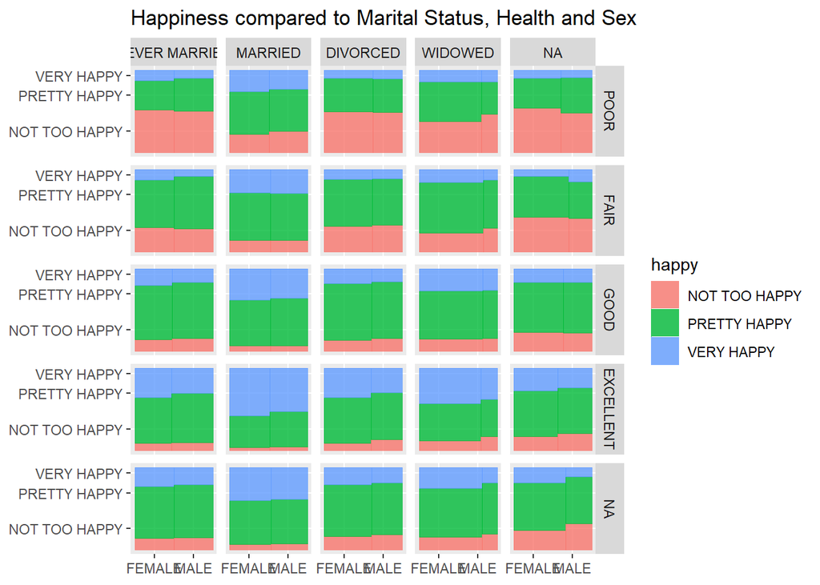

```r
ggplot(HAPPY)+geom_mosaic(aes(x =product(sex),fill = happy),offset = 0,na.rm = TRUE, divider = mosaic())+facet_grid(health~marital) + labs(title = 'Happiness compared to Marital Status, Health and Sex') + xlab(NULL) + ylab(NULL)
```

In this mosaic we are comparing Happiness in regards to health, sex and marital status. We can see a slight relationship that being married leads to people being happier. We can also see a clear trend that better health leads to happier people. Sex did not appear to have any consistent pattern in regards to happiness. Of the three, health seemed to have the most impact on happiness.

## Conclusions

From our mosaic we can conclude that health and being married have the greatest positive relationship towards happiness in regards, to health, marital status and sex. Further study could be done in these areas to see if this correlation has any causation or is just coincidence. `